# Moving Beyond Linearity

Tugas Praktikum 8 STA581 Sains Data

Nur Andi Setiabudi[^1]

2021-11-03

# Pendahuluan

## Tujuan

- Melakukan *cross validation* untuk menghasilkan pemodelan antara tingkat efisiensi penggunaan bahan bakar (direpresentasikan oleh`mpg` atau *miles per gallon*) *versus* tiga peubah prediktor yang pada data `ISLR::Auto` dengan metode:
  - *Polynomial regression*
  - *Piecewise constant*
  - *Natural cubic splines*
- Pemodelan dilakukan untuk masing-masing peubah prediktor terpilih.

## Output

Mendapatkan model non-linier yang optimal untuk masing-masing peubah prediktor.

# Metodologi

## Tahapan

Pemodelan dilakukan dengan tahapan sebagai berikut:

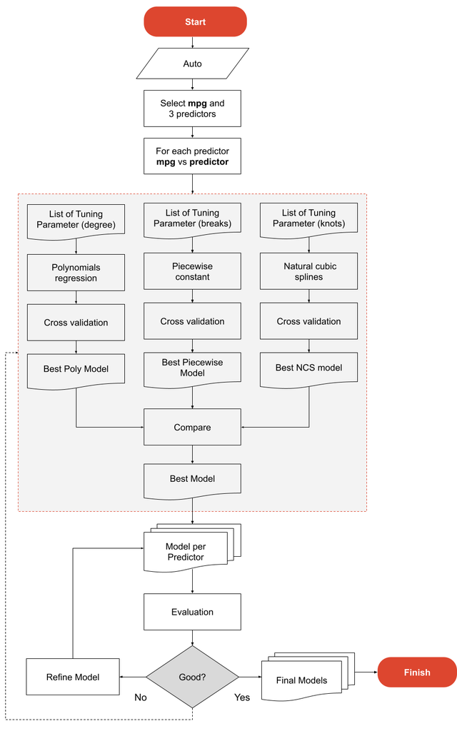

## Skenario *Tuning Parameter*

- *Cross validation*

  Derajat/*degree* polinomial awal: `c(2:10)`
- *Piecewise constant*

  Jumlah *bins*/*breaks* awal: `c(2:10)`
- *Natural Cubic Spline*

  Jumlah dan lokasi *knots* awal ditentukan perdasarkan *quantile*:

| Jumlah *knots* | Lokasi *knots* (*quantiles*) |
| --- | --- |
| 1 | `.5,` |
| 2 | `.33 * c(1:2)` |
| 3 | `.25 * c(1:3)` |
| 3* | `c(.10, .5, .90)` |
| 4 | `.20 * c(1:4)` |
| 4* | `c(.05, .35, .65, .95)` |
| 5 | `.167 * c(1:5)` |
| 5* | `c(.05, .275, .5, .725, .95)` |
| 6 | `.143 * c(1:6)` |
| 6* | `c(.05, .23, .41, .59, .77, .95)` |
| 7 | `.125 * c(1:7)` |
| 7* | `c(.025, .1833, .3417, .5, .6583, .8167, .975)` |

Sumber : Frank E. Harrell, Jr. (2015). *Regression Modeling Strategies*

## *Tools*

- R
- `splines` dan `stats` untuk pemodelan
- `caret` untuk *cross validation*
- `ggplot2` dan `cowplot` untuk grafik/visualisasi

## Kumpulan Fungsi

Untuk memudahkan iterasi, dibuat beberapa fungsi:

### *Modeling* dan *Cross Validation*

```r
library(splines)
library(caret)

beyondLinear <- function(df, y, x, model, param){

  #' beyondLinear()
  #'
  #' Perform k-fold cross validation for Polynomial, Piecewise, Natural Cubic Spline
  #' and select the best model based on RMSE
  #'
  #' Input:
  #' df: data-frame, ex: Auto
  #' y: quoted y-variable, ex: "mpg"
  #' x: quoted x-variable, ex: "horsepower"
  #' model: model/algorithm: polynomial, piecewise, ncubicspline
  #' param: tuning parameter

  cvResult <- mapply(
    function(param, model){

      if (model == "polynomial"){
        f <- sprintf("%s ~ poly(%s, degree = %s)", y, x, param)
      } else if (model == "piecewise") {
        f <- sprintf("%s ~ cut(%s, breaks = %s)", y, x, param)
      } else if (model == "ncubicspline") {
        f <- sprintf("%s ~ ns(%s, knots = c(%s))", y, x, paste(param, collapse = ","))
      } else if (model == "smoothspline") {
        f <- smooth.spline(cars[,"speed"], cars[,"dist"], df = param)
      }

      trCtl <- trainControl(method='cv', number = 10)
      models <- train(as.formula(f), data = df, trControl = trCtl, method = 'glm')

      RMSE <- models$results$RMSE
      fModel <- models$finalModel

      return(list(models, RMSE, fModel))
    },  model = model, param = param, USE.NAMES = FALSE, SIMPLIFY = FALSE )


  if(!is.null(names(param))){
    paramIdx <- names(param)
  } else {
    paramIdx <- param
  }

  cvScore <- data.frame(paramIdx = as.character(unlist(paramIdx)),
                        score = unlist(sapply(cvResult, "[", 2, USE.NAMES = F)))
  cvScore$param <- param

  bestPos <- which.min(cvScore$score)[1]
  bestParam <- param[[bestPos]]
  bestScore <- cvResult[[bestPos]][[2]]
  bestModel <- cvResult[[bestPos]][[1]]

  predValue <- data.frame(df[c(y,x)],
                          pred = predict(bestModel, df, interval = "prediction"))

  return(list(method = model,
              cvScore = cvScore,
              whichBest = bestPos,
              bestParamIdx = paramIdx[bestPos],
              bestParam = bestParam,
              bestScore = bestScore,
              bestModel = bestModel,
              predValue = predValue))
}
```

### Grafik

```r
library(ggplot2)
library(cowplot)

cvPlot <- function(df, title, xlab){

  #' cvPlot()
  #'
  #' Create cross-validation plot for Polynomial, Piecewise, Natural Cubic Spline
  #' based on given tuning parameters

  scaleFUN <- function(x) as.character(round(x,2))
  df$paramIdx <- factor(df$paramIdx, levels = df$paramIdx)

  ggplot(df, aes(x=paramIdx, y=score)) +
    geom_bar(stat = "identity", width=0.1, fill = "black") +
    coord_cartesian(ylim = c(0.99*min(df$score), NA)) +
    geom_hline(yintercept = min(df$score), linetype="dashed", color = "red") +
    ggtitle(title) +
    xlab(xlab) + ylab("CV Root Mean Squared Error") +
    theme_classic()
}

predPlot <- function(df, y, laby, x, labx, title){

  #' predPlot()
  #'
  #' Create plot of best model's fitted value vs response
  #' Along with its observed values

  ggplot(df) +
    geom_point(aes_string(x = x, y = y, fill = as.factor(1))) +
    geom_line(aes_string(x = x, y = "pred", color = as.factor(1)), size = 1) +
    scale_fill_manual(labels = c("Observed"), values = c("black")) +
    scale_color_manual(labels = c("Predicted"), values = c("blue"))  +
    theme_classic() +
    ggtitle(title) +
    xlab(labx) + ylab(laby) +
    theme(legend.title = element_blank(),
          legend.position = "bottom",
          legend.box = "horizontal")
}

predPlotAll <- function(df, y, x, laby, labx) {

  #' predPlotAll()
  #'
  #' Create plot of all best model's fitted value vs response
  #' In one frame

  ggplot(df) +
    geom_point(aes_string(x = x, y = y, fill = as.factor(1))) +
    geom_line(aes_string(x = x, y = "polynomial", color = as.factor(2)), size = 1) +
    geom_line(aes_string(x = x, y = "piecewise", color = as.factor(3)), size = 1) +
    geom_line(aes_string(x = x, y = "ncubicspline", color = as.factor(4)), size = 1) +
    scale_fill_manual(labels = c("Observed"), values = c("black")) +
    scale_color_manual(labels = c("Polynomial", "Piecewise", "Natural Cubic Splines"),
                       values = c("blue", "red", "green"))  +
    theme_classic() +
    ggtitle("Comparison of Best Predictions") +
    xlab(labx) + ylab(laby) +
    theme(legend.title = element_blank(),
          legend.position = "bottom",
          legend.box = "horizontal")
}
```

### Fungsi *wrapper*

```r
generateAllREg <- function(df, y, x, laby, labx, degree, cut, knot, best=NULL){

  #' generateAllREg()
  #'
  #' Wrapper function to call
  #'   beyondLinear()
  #'   cvPlot()
  #'   predPlot()
  #' in one call

  methods <- c("polynomial", "piecewise", "ncubicspline")
  method_alias <- c("Polynomial Regression", "Piecewise Constant", "Natural Cubic Splines")
  params <- list(Degree = degree, `N Bins` = cut, `N Knots` = knot)

  outModel <- list()
  pltCV <- list()
  pltPred <- list()

  for( i in seq(length(methods)) ){

    model <- beyondLinear(df = df, y = y, x = x, model = methods[i], param = params[[i]])

    outModel[[i]] <- model


    p <- cvPlot(model$cvScore,
                title = method_alias[i],
                xlab =  names(params)[i])

    pltCV[[i]] <- p

    p <- predPlot(df = model$predValue,
                  y = y, laby = laby,
                  x = x, labx = labx,
                  title = sprintf("%s with %s=%s (RMSE=%s)",
                                  method_alias[i], names(params)[i],
                                  model$bestParamIdx, round(model$bestScore,2)))

    if(methods[i] == "ncubicspline"){
      p <- p + geom_vline(xintercept = model$bestParam, linetype="dashed", color = "gray")
    }

    pltPred[[i]] <- p
  }

  bestSummary <- data.frame(t(sapply(outModel, "[", c("method", "bestParamIdx", "bestScore"))))
  names(bestSummary) <- c("method", "param", "RMSE")

  predAllBest <- data.frame(outModel[[1]]$predValue,
                            outModel[[2]]$predValue$pred,
                            outModel[[3]]$predValue$pred)
  names(predAllBest) <- c(y, x, methods)

  pltPredAll <- predPlotAll(df = predAllBest,
                          y = y, x = x,
                          laby = laby, labx = labx)

    if(is.null(best)){
      bIdx <- which.min(bestSummary$RMSE)
    } else {
      bIdx <- best
    }

  bestModel <- bestSummary[bIdx, ]

  predicted <- outModel[[bIdx]]$predValue

  return(list(bestSummary = bestSummary,
              bestModel = bestModel,
              bestModelDetail = outModel[[bIdx]]$bestModel,
              bestParamDetail = outModel[[bIdx]]$bestParam,
              model = outModel,
              pltCV = pltCV,
              pltPred = pltPred,
              pltPredAll = pltPredAll,
              pltCVGrid = plot_grid(pltCV[[1]], pltCV[[2]], pltCV[[3]]),
              pltPredGrid = plot_grid(pltPred[[1]], pltPred[[2]], pltPred[[3]], pltPredAll),
              predBest3 = predAllBest,
              predBestFinal = predicted))

}
```

### Penentuan *Knots*

```r
pctKnots <- function(x){

  #' pctKnots()
  #'
  #' Calculate knots based on quartiles

  pct <- list(
    .5,
    .33*c(1:2),
    .25*c(1:3),
    c(.10,.5,.90),
    .20*c(1:4),
    c(.05,.35,.65,.95),
    .167*c(1:5),
    c(.05,.275,.5,.725,.95),
    .143*c(1:6),
    c(.05,.23,.41,.59,.77,.95),
    .125*c(1:7),
    c(.025,.1833,.3417,.5,.6583,.8167,.975))

  knt <- sapply(pct, function(p, i){round(quantile(i, p),2)}, i = x)
  names(knt) <- c(1,2,3,"3*",4,"4*",5,"5*",6,"6*",7,"7*")
  return(knt)

}
```

# Hasil dan Pembahasan

## Preview Dataset

```r
library(ISLR)
head(Auto)
```

| mpg | cylinders | displacement | horsepower | weight | acceleration | year | origin | name |
| --- | --- | --- | --- | --- | --- | --- | --- | --- |
| 18 | 8 | 307 | 130 | 3504 | 12.0 | 70 | 1 | chevrolet chevelle malibu |
| 15 | 8 | 350 | 165 | 3693 | 11.5 | 70 | 1 | buick skylark 320 |
| 18 | 8 | 318 | 150 | 3436 | 11.0 | 70 | 1 | plymouth satellite |
| 16 | 8 | 304 | 150 | 3433 | 12.0 | 70 | 1 | amc rebel sst |
| 17 | 8 | 302 | 140 | 3449 | 10.5 | 70 | 1 | ford torino |
| 15 | 8 | 429 | 198 | 4341 | 10.0 | 70 | 1 | ford galaxie 500 |

```r
summary(Auto)
```

```
##       mpg          cylinders      displacement     horsepower        weight
##  Min.   : 9.00   Min.   :3.000   Min.   : 68.0   Min.   : 46.0   Min.   :1613
##  1st Qu.:17.00   1st Qu.:4.000   1st Qu.:105.0   1st Qu.: 75.0   1st Qu.:2225
##  Median :22.75   Median :4.000   Median :151.0   Median : 93.5   Median :2804
##  Mean   :23.45   Mean   :5.472   Mean   :194.4   Mean   :104.5   Mean   :2978
##  3rd Qu.:29.00   3rd Qu.:8.000   3rd Qu.:275.8   3rd Qu.:126.0   3rd Qu.:3615
##  Max.   :46.60   Max.   :8.000   Max.   :455.0   Max.   :230.0   Max.   :5140
##
##   acceleration        year           origin                      name
##  Min.   : 8.00   Min.   :70.00   Min.   :1.000   amc matador       :  5
##  1st Qu.:13.78   1st Qu.:73.00   1st Qu.:1.000   ford pinto        :  5
##  Median :15.50   Median :76.00   Median :1.000   toyota corolla    :  5
##  Mean   :15.54   Mean   :75.98   Mean   :1.577   amc gremlin       :  4
##  3rd Qu.:17.02   3rd Qu.:79.00   3rd Qu.:2.000   amc hornet        :  4
##  Max.   :24.80   Max.   :82.00   Max.   :3.000   chevrolet chevette:  4
##                                                  (Other)           :365
```

### Hubungan `mpg` terhadap peubah-peubah lain

Diagram pencar di bawah menunjukkan hubungan peubah `mpg` terhadap peubah-peubah lain yang ada dalam dataset, yaitu:

- `cylinders`
- `displacement`
- `horsepower`
- `weight`
- `year`

```r
plotmpg <- function(x){
  ggplot(Auto) +
  geom_point(aes_string(x = tolower(x), y = "mpg"), alpha = 0.8) +
  ggtitle(paste0("Miles per Gallon vs ", x)) +
  xlab(x) + ylab("Miles per Gallon") +
  theme_classic()
}
```

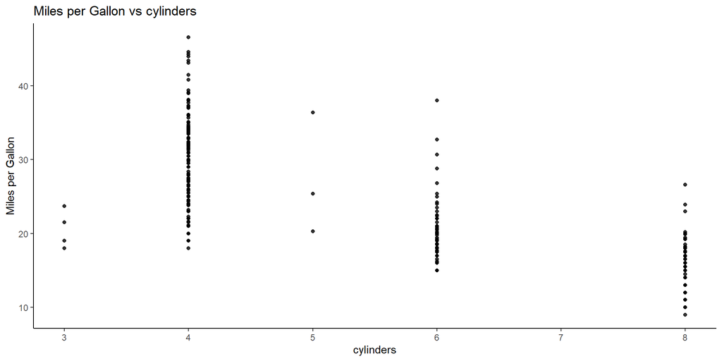

```r
p1 <- plotmpg("cylinders")
p1
```

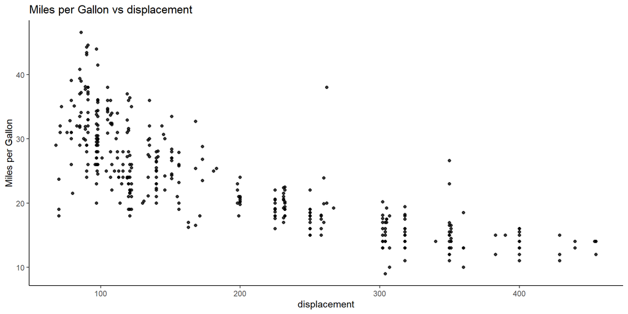

```r
p2 <- plotmpg("displacement")
p2
```

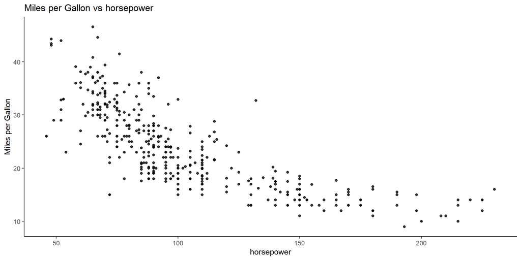

```r
p3 <- plotmpg("horsepower")
p3
```

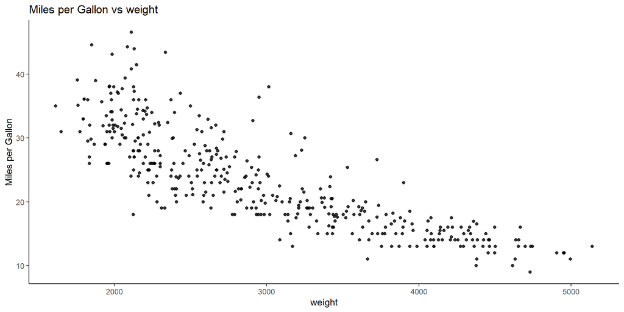

```r
p4 <- plotmpg("weight")
p4
```

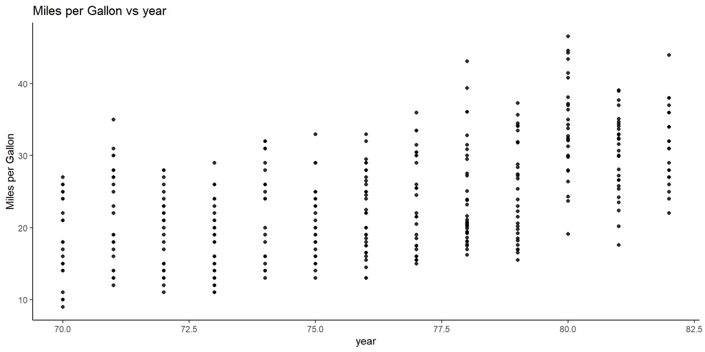

```r
p5 <- plotmpg("year")
p5
```

Jika disatukan dalam satu frame, maka dapat dilihat:

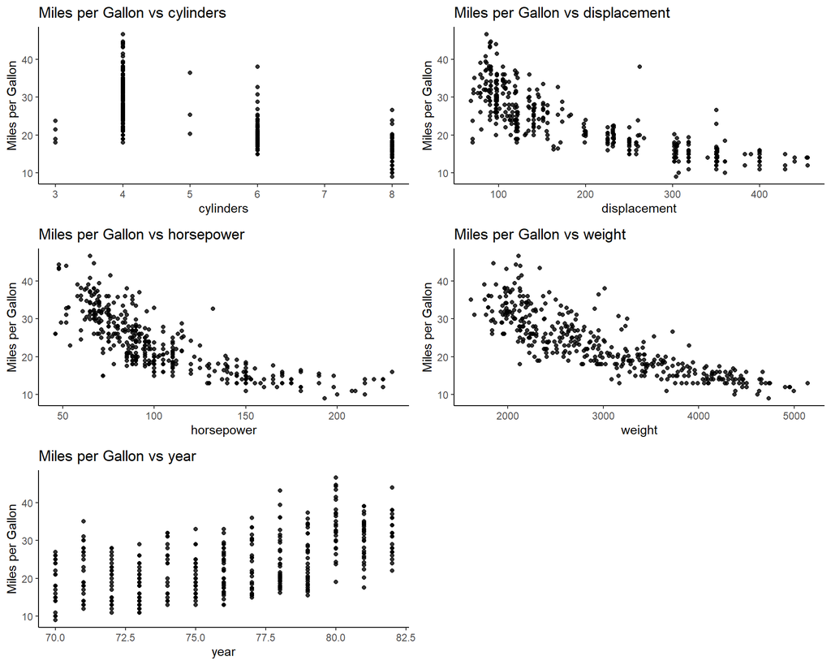

```r
plot_grid(p1, p2, p3, p4, p5, ncol = 2)
```

Berdasarkan diagram pencar di atas, maka terlihat hubungan `mpg` dengan peubah-peubah lain bersifat tidak linier.

Untuk proses selanjutnya, akan dipilih tiga peubah sebagai prediktor bagi `mpg`, yaitu `displacement`, `horsepower` dan `weight`.

## `mpg` versus `displacement`

```r
AutoKnots <- pctKnots(Auto$displacement)

set.seed(123)
mpg.dp <- generateAllREg(df = Auto,
                         y = "mpg", x = "displacement",
                         laby = "Miles per Gallon", labx = "Displacement",
                         degree = c(2:10), cut = c(2:10), knot = AutoKnots,
                         best = 2)
```

### *Cross validation*

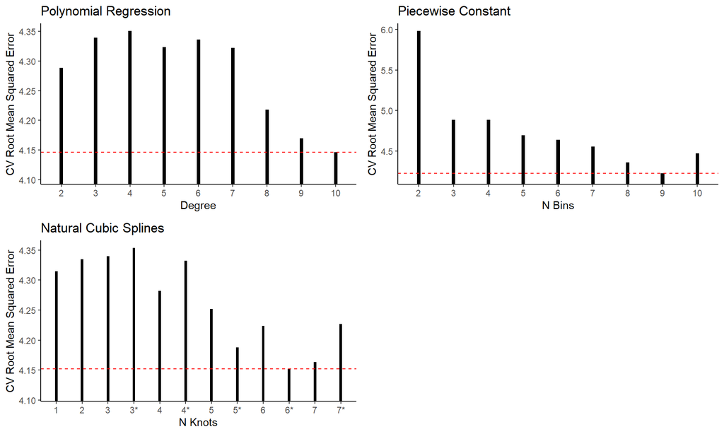

```r
mpg.dp$pltCVGrid
```

### Ringkasan *tuning parameter* terbaik

```r
mpg.dp$bestSummary
```

| method | param | RMSE |
| --- | --- | --- |
| polynomial | 10 | 4.146329 |
| piecewise | 9 | 4.222382 |
| ncubicspline | 6* | 4.15199 |

```r
mpg.dp$bestModel
```

|  | method | param | RMSE |
| --- | --- | --- | --- |
| 2 | piecewise | 9 | 4.222382 |

*Tunning Parameter* terbaik:

```r
mpg.dp$bestParamDetail
```

```
## [1] 9
```

### Nilai observasi *vs* prediksi

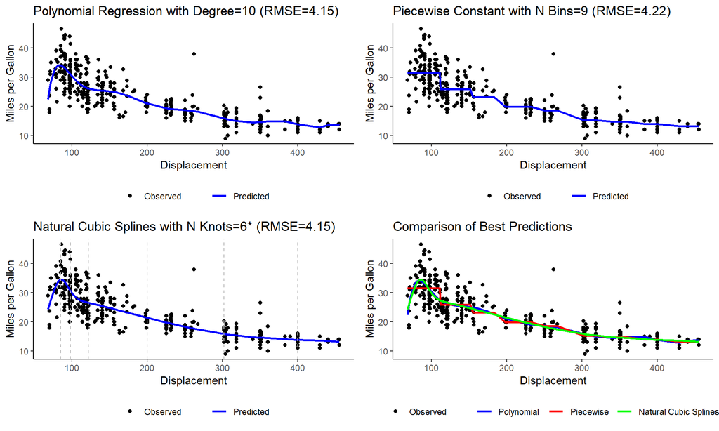

```r
mpg.dp$pltPredGrid
```

Model terbaik yang diperoleh dari *cross-validation* adalah *polynomial* derajat 10 yang memberikan RMSE 4.15. Akan tetapi, dari kurva terlihal nilai prediksi *polynomial* dan *natural cubic splines* menunjukkan ada belokan di ujung sebelah kiri kurva. Karena itu, dipilih model lainnya yaitu *piecewise constant* dengan jumlah tangga 9. Konsekuensinya, RMSE meningkat menjadi 4.22.

### Ringkasan *modeling*

```r
summary(mpg.dp$bestModelDetail)
```

```
##
## Call:
## NULL
##
## Deviance Residuals:
##      Min        1Q    Median        3Q       Max
## -13.5181   -2.2250   -0.2905    2.0339   19.4607
##
## Coefficients:
##                                          Estimate Std. Error t value Pr(>|t|)
## (Intercept)                               31.5181     0.3947  79.850  < 2e-16
## `cut(displacement, breaks = 9)(111,154]`  -5.5601     0.6010  -9.252  < 2e-16
## `cut(displacement, breaks = 9)(154,197]`  -8.2848     1.0770  -7.693 1.23e-13
## `cut(displacement, breaks = 9)(197,240]` -11.7022     0.7527 -15.547  < 2e-16
## `cut(displacement, breaks = 9)(240,283]` -12.9788     0.8951 -14.499  < 2e-16
## `cut(displacement, breaks = 9)(283,326]` -16.2276     0.7656 -21.197  < 2e-16
## `cut(displacement, breaks = 9)(326,369]` -16.7923     0.8595 -19.537  < 2e-16
## `cut(displacement, breaks = 9)(369,412]` -17.5494     1.1337 -15.479  < 2e-16
## `cut(displacement, breaks = 9)(412,455]` -18.2959     1.4710 -12.438  < 2e-16
##
## (Intercept)                              ***
## `cut(displacement, breaks = 9)(111,154]` ***
## `cut(displacement, breaks = 9)(154,197]` ***
## `cut(displacement, breaks = 9)(197,240]` ***
## `cut(displacement, breaks = 9)(240,283]` ***
## `cut(displacement, breaks = 9)(283,326]` ***
## `cut(displacement, breaks = 9)(326,369]` ***
## `cut(displacement, breaks = 9)(369,412]` ***
## `cut(displacement, breaks = 9)(412,455]` ***
## ---
## Signif. codes:  0 '***' 0.001 '**' 0.01 '*' 0.05 '.' 0.1 ' ' 1
##
## (Dispersion parameter for gaussian family taken to be 18.07284)
##
##     Null deviance: 23819.0  on 391  degrees of freedom
## Residual deviance:  6921.9  on 383  degrees of freedom
## AIC: 2258
##
## Number of Fisher Scoring iterations: 2
```

## `mpg` versus `horsepower`

```r
AutoKnots <- pctKnots(Auto$horsepower)

set.seed(123)
mpg.hp <- generateAllREg(df = Auto,
                         y = "mpg", x = "horsepower",
                         laby = "Miles per Gallon", labx = "Horsepower",
                         degree = c(2:10), cut = c(2:10), knot = AutoKnots)
```

### *Cross validation*

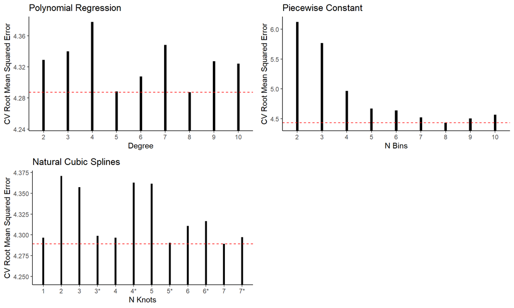

```r
mpg.hp$pltCVGrid
```

### Ringkasan *tuning parameter* terbaik

```r
mpg.hp$bestSummary
```

| method | param | RMSE |
| --- | --- | --- |
| polynomial | 8 | 4.287447 |
| piecewise | 8 | 4.430233 |
| ncubicspline | 7 | 4.289125 |

```r
mpg.hp$bestModel
```

| method | param | RMSE |
| --- | --- | --- |
| polynomial | 8 | 4.287447 |

*Tunning Parameter* terbaik:

```r
mpg.hp$bestParamDetail
```

```
## [1] 8
```

### Nilai observasi *vs* prediksi

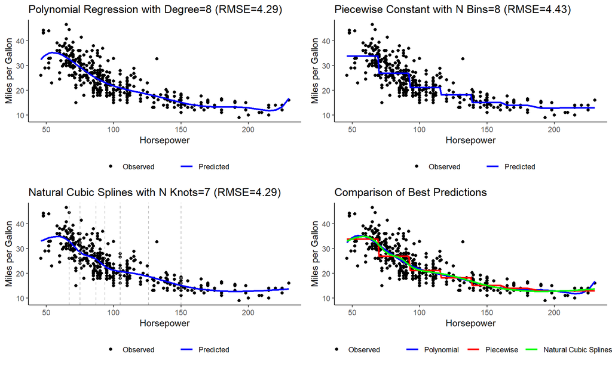

```r
mpg.hp$pltPredGrid
```

Model terbaik yang diperoleh dari *cross-validation* adalah *polynomial* derajat 8.

### Ringkasan *modeling*

```r
summary(mpg.hp$bestModelDetail)
```

```
##
## Call:
## NULL
##
## Deviance Residuals:
##      Min        1Q    Median        3Q       Max
## -15.5939   -2.5657   -0.2684    2.2188   15.1306
##
## Coefficients:
##                                  Estimate Std. Error t value Pr(>|t|)
## (Intercept)                       23.4459     0.2172 107.953  < 2e-16 ***
## `poly(horsepower, degree = 8)1` -120.1377     4.3001 -27.939  < 2e-16 ***
## `poly(horsepower, degree = 8)2`   44.0895     4.3001  10.253  < 2e-16 ***
## `poly(horsepower, degree = 8)3`   -3.9488     4.3001  -0.918  0.35903
## `poly(horsepower, degree = 8)4`   -5.1878     4.3001  -1.206  0.22839
## `poly(horsepower, degree = 8)5`   13.2722     4.3001   3.086  0.00217 **
## `poly(horsepower, degree = 8)6`   -8.5462     4.3001  -1.987  0.04758 *
## `poly(horsepower, degree = 8)7`    7.9806     4.3001   1.856  0.06423 .
## `poly(horsepower, degree = 8)8`    2.1727     4.3001   0.505  0.61366
## ---
## Signif. codes:  0 '***' 0.001 '**' 0.01 '*' 0.05 '.' 0.1 ' ' 1
##
## (Dispersion parameter for gaussian family taken to be 18.49066)
##
##     Null deviance: 23819.0  on 391  degrees of freedom
## Residual deviance:  7081.9  on 383  degrees of freedom
## AIC: 2266.9
##
## Number of Fisher Scoring iterations: 2
```

## `mpg` versus `weight`

```r
AutoKnots <- pctKnots(Auto$weight)

set.seed(123)
mpg.wg <- generateAllREg(df = Auto,
                         y = "mpg", x = "weight",
                         laby = "Miles per Gallon", labx = "Weight",
                         degree = c(2:10), cut = c(2:10), knot = AutoKnots)
```

### *Cross validation*

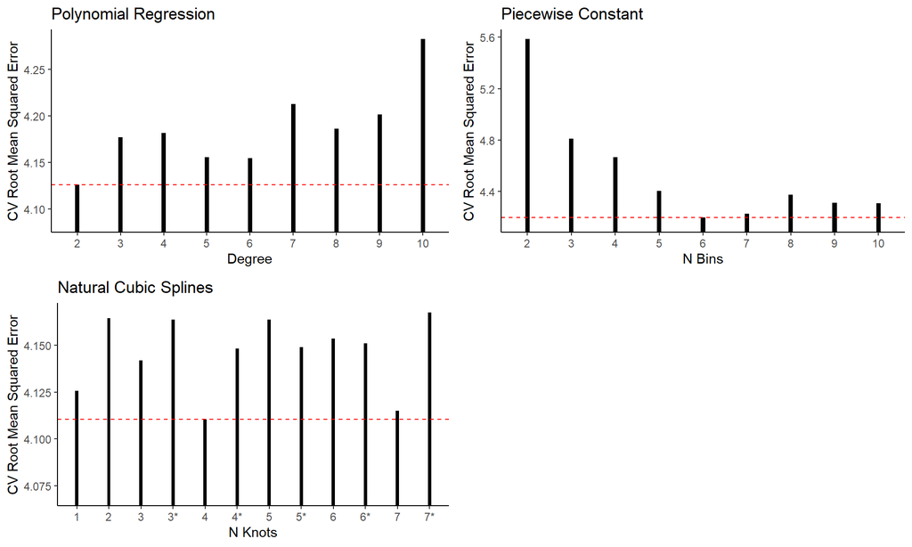

```r
mpg.wg$pltCVGrid
```

### Ringkasan *tuning parameter* terbaik

```r
mpg.wg$bestSummary
```

| method | param | RMSE |
| --- | --- | --- |
| polynomial | 2 | 4.126055 |
| piecewise | 6 | 4.197694 |
| ncubicspline | 4 | 4.11046 |

```r
mpg.wg$bestModel
```

|  | method | param | RMSE |
| --- | --- | --- | --- |
| 3 | ncubicspline | 4 | 4.11046 |

*Tunning Parameter* terbaik:

```r
mpg.wg$bestParamDetail
```

```
##    20%    40%    60%    80%
## 2155.0 2583.2 3113.4 3820.8
```

### Nilai observasi *vs* prediksi

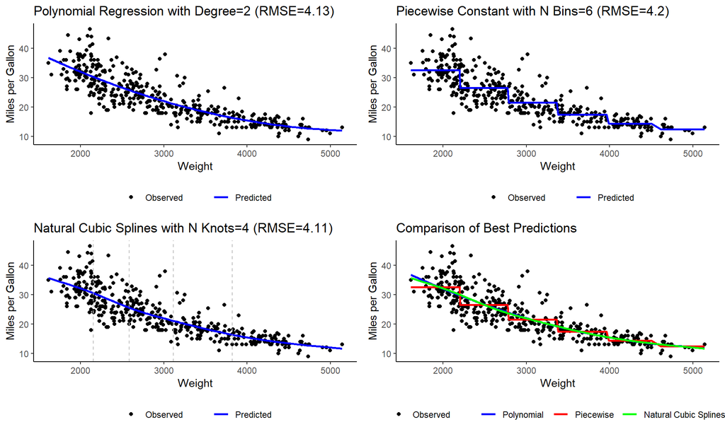

```r
mpg.wg$pltPredGrid
```

### Ringkasan *modeling*

```r
summary(mpg.wg$bestModelDetail)
```

```
##
## Call:
## NULL
##
## Deviance Residuals:
##      Min        1Q    Median        3Q       Max
## -12.8856   -2.7740   -0.4045    1.9150   16.1559
##
## Coefficients:
##                                                        Estimate Std. Error
## (Intercept)                                              35.686      1.591
## `ns(weight, knots = c(2155, 2583.2, 3113.4, 3820.8))1`  -10.885      1.553
## `ns(weight, knots = c(2155, 2583.2, 3113.4, 3820.8))2`  -15.031      1.991
## `ns(weight, knots = c(2155, 2583.2, 3113.4, 3820.8))3`  -19.698      1.433
## `ns(weight, knots = c(2155, 2583.2, 3113.4, 3820.8))4`  -26.677      3.648
## `ns(weight, knots = c(2155, 2583.2, 3113.4, 3820.8))5`  -21.759      1.674
##                                                        t value Pr(>|t|)
## (Intercept)                                             22.423  < 2e-16 ***
## `ns(weight, knots = c(2155, 2583.2, 3113.4, 3820.8))1`  -7.010 1.07e-11 ***
## `ns(weight, knots = c(2155, 2583.2, 3113.4, 3820.8))2`  -7.549 3.20e-13 ***
## `ns(weight, knots = c(2155, 2583.2, 3113.4, 3820.8))3` -13.745  < 2e-16 ***
## `ns(weight, knots = c(2155, 2583.2, 3113.4, 3820.8))4`  -7.312 1.53e-12 ***
## `ns(weight, knots = c(2155, 2583.2, 3113.4, 3820.8))5` -12.997  < 2e-16 ***
## ---
## Signif. codes:  0 '***' 0.001 '**' 0.01 '*' 0.05 '.' 0.1 ' ' 1
##
## (Dispersion parameter for gaussian family taken to be 17.53828)
##
##     Null deviance: 23819.0  on 391  degrees of freedom
## Residual deviance:  6769.8  on 386  degrees of freedom
## AIC: 2243.2
##
## Number of Fisher Scoring iterations: 2
```

# Kesimpulan

Berdasarkan hasil modeling tidak linier, pemilihan *tuning parameter* menggunakan *10-fold cross validation*, dan evaluasi diperoleh model terbaik untuk masing-masing prediktor sebagai berikut:

```r
summary3 <- rbind(
    cbind(predictor = "displacement", mpg.dp$bestModel, paramlist = paste0(mpg.dp$bestParamDetail, collapse = ",")),
    cbind(predictor = "horsepower",   mpg.hp$bestModel, paramlist = paste0(mpg.hp$bestParamDetail, collapse = ",")),
    cbind(predictor = "weight",       mpg.wg$bestModel, paramlist = paste0(mpg.wg$bestParamDetail, collapse = ",")))

row.names(summary3) <- NULL
summary3 <- summary3[, c(1,2,3,5,4)]
summary3
```

| predictor | method | param | paramlist | RMSE |
| --- | --- | --- | --- | --- |
| displacement | piecewise | 9 | 9 | 4.222382 |
| horsepower | polynomial | 8 | 8 | 4.287447 |
| weight | ncubicspline | 4 | 2155,2583.2,3113.4,3820.8 | 4.11046 |

Hasil modeling dapat disajikan dalam diagram pencar dan kurva prediksi sebagai berikut:

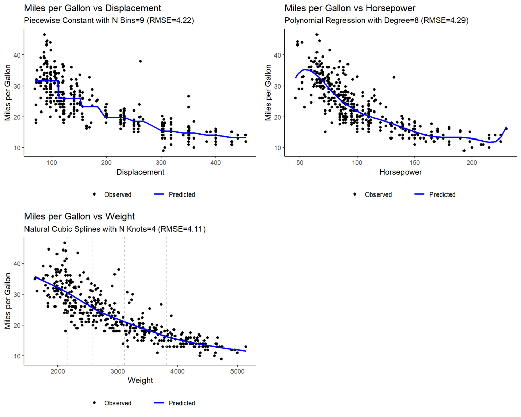

```r
plt.dp <- mpg.dp$pltPred[[2]]
plt.dp <- plt.dp + ggtitle("Miles per Gallon vs Displacement", subtitle = plt.dp$labels$title)

plt.hp <- mpg.hp$pltPred[[1]]
plt.hp <- plt.hp + ggtitle("Miles per Gallon vs Horsepower", subtitle = plt.hp$labels$title)

plt.wg <- mpg.wg$pltPred[[3]]
plt.wg <- plt.wg + ggtitle("Miles per Gallon vs Weight", subtitle = plt.wg$labels$title)

plot_grid(plt.dp, plt.hp, plt.wg)
```

Meskipun sudah mendapatkan “model terbaik”, *tuning model* masih perlu dilakukan terutama untuk prediktor *horsepower* karena masih ada belokan di ujung-ujung kurva.

# Daftar Pustaka

Dito, Gerry A. (2021), *Regresi Polinomial, Regresi Fungsi Tangga dan Regresi Spline di R*, https://gerrydito.github.io/Regresi-Polinomial,-Regresi-Fungsi-Tangga-dan-Regresi-Spline/ (Oct 29, 2021).

Harrell, Frank E., Jr. (2015). *Regression Modeling Strategies. Springer Series in Statistics*, Springer.

James, G.; Witten, D.; Hastie, T. & Tibshirani, R. (2013), *An Introduction to Statistical Learning: with Applications in R*, Springer.

[^1]: Mahasiswa Pascasarjana Statistika dan Sains Data, Institut Pertanian Bogor, NIM: G1501211061, nur.andi@apps.ipb.ac.id